# DEFINISI QUEUE

Queues atau antrian merupakan struktur data dimana penambahan data baru dan penghapusan data berada di ujung yang berbeda. Hal ini berbeda dengan stacks, dimana penambahan databaru dan penghapusan data, dilakukan pada ujung yang sama.

Pada Queues, seperti halnya antrian, penambahan data baru dilakukan di suatu ujung atau yang dikenal dengan nama rear, dan penghapusan data dilakukan pada ujung yang dikenal dengan nama front, seperti yang terlihat pada Gambar 1 berikut :

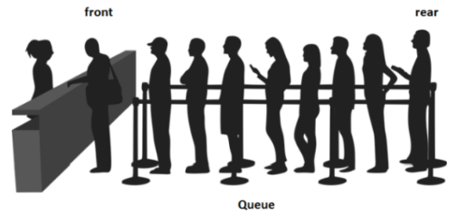

queue menggunakan prinsip FIFO (first in first out)

## OPERASI QUEUE:

- queue (), inisialisasi struktur data queue kosong
- enqueue (data), penambahan *data* baru pada queue
- dequeue (), penghapusan data
- isEmpty(), pengecekan apakah queue dalam keadaan kosong
- size (), informasi jumlah data yang terdapat pada queue

ilustrasi penambahan dan penghapusan data:

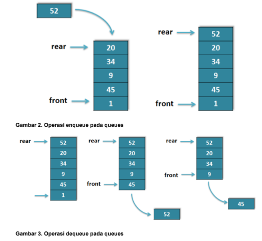

Pada Gambar 2 ditunjukkan bahwa penambahan data baru (enqueue) dilakukan pada ujung data 'rear', sedangkan penghapusan data (dequeque) dilakukan pada ujung data 'front', karena sifat queues yang FIFO.

Implementasi queues dapat dilakukan pada tipe data lists. Data pada indeks terakhir pada list adalah merupakan data yang terletak pada ujung front pada queues. Sehingga proses dequeue dilakukan dengan menggunakan method pop pada list.

Sedangkan data pada indeks awal, atau indeks ke-0 dari list, menunjukkan data yang terletak pada posisi rear dari queues. Oleh karena itu proses enqueue dilakukan dengan method insert pada posisi 0 dari list.

Misalkan terdapat data berbentuk list, sebagai berikut :

data=[8, 3, 9, 2]

Jika dilakukan data.insert(0,74) , atau penambahan data pada posisi rear, maka data akan berubah menjadi :

data=[74, 8, 3, 9, 2]

Jika dilakukan data.pop() , atau penghapusan data pada posisi front, maka data akan berubah menjadi :

data=[74, 8, 3, 9]

```python
def queue():
  q=[]
  return q
def enqueue(q, data):
  q.append (data)
  return q
def dequeue(q):
  data=q.pop(0)
  return (data)
def isempty(q):
  return (q==[])
```

```python
antrian= queue()
enqueue(antrian, "A")
enqueue(antrian, "B")
print (antrian)

dequeue(antrian)
print(antrian)
```

```
['A', 'B']
['B']
```

```python
antre=queue()
enqueue(antre,'fajar')
enqueue(antre,'adi')
enqueue(antre,'putra')
enqueue(antre,'ali')
enqueue(antre,'jefri')
print(antre)

antre2=queue()
while not isempty(antre):
  a=dequeue(antre)
  if a != "putra":
    enqueue(antre2, a)
print(antre2)
```

```
['fajar', 'adi', 'putra', 'ali', 'jefri']
['fajar', 'adi', 'ali', 'jefri']
```

```python
#challenge1
detik=0
q_kereta=queue()
enqueue(q_kereta, "A")
enqueue(q_kereta, "B")
enqueue(q_kereta, "C")
enqueue(q_kereta, "D")
enqueue(q_kereta, "E")
target="D"
while True:
  cari=dequeue(q_kereta)
  cari2=dequeue(q_kereta)
  if cari != target:
    enqueue(q_kereta, cari )
    enqueue(q_kereta, cari2)
  else:
    break
  detik+=1
  print('detik= ', detik)
  print('kereta= ',q_kereta )
```

```
detik=  1
kereta=  ['C', 'D', 'E', 'A', 'B']
detik=  2
kereta=  ['E', 'A', 'B', 'C', 'D']
detik=  3
kereta=  ['B', 'C', 'D', 'E', 'A']
detik=  4
kereta=  ['D', 'E', 'A', 'B', 'C']
```

```python
#challenge2
antri=queue()
enqueue(antri,"fajar")
enqueue(antri,"putra")
enqueue(antri,"ali")
enqueue(antri,"ifud")
enqueue(antri,"jefri")

menit=int(input("masukkan menit: "))
tahap=menit//20
for i in range (tahap+1):
  if not isempty(antri):
    b=dequeue(antri)
    sekarang=b
  else:
    sekarang="kosong"
print("yang dilayani sekarang adalah: ", sekarang)
```

```
yang dilayani sekarang adalah:  ali
```

```python
def biner(angka):
  if angka==0:
    return "0"
  else:
    stack=[]
    langkah=[]
    while angka>0:
      sisa=angka%2
      stack.append(sisa)
      langkah.append("push stack with "+str(sisa))
      angka//=2
    hasil=""
    while len(stack) > 0:
        hasil += str(stack.pop())
        langkah.append("pop stack")

    return hasil, langkah

hasil, langkah = biner(57)

for i in range(len(langkah)):
    print(f"{langkah[i]}")

print("\nBiner =", hasil)
```

```
push stack with 1
push stack with 0
push stack with 0
push stack with 1
push stack with 1
push stack with 1
pop stack
pop stack
pop stack
pop stack
pop stack
pop stack

Biner = 111001
```

```python
def parenthesesCheck(math):
  buka="([{"
  tutup=")]}"
  stack=[]
  proses=[]
  error=[]

  for i in math:
    if i in buka:
      stack.append(i)
      proses.append("push stack with "+ i + "--->" + str(stack))
    elif i in tutup:
      if len(stack)==0:
        error.append("kurang tutup "+ i + "tidak punya pasangan")
      else:
        ambil=stack.pop()
        proses.append("pop stack --->"+ str(stack))

        if i==")" and ambil !="(":
          error.append("kurang buka "+ ambil + " tidak cocok dengan kurung tutup ')'")
        elif  i=="]" and ambil!="[":
          error.append("kurung buka "+ ambil + " tidak cocok dengan kurung tutup ']'")
        elif i=="}" and ambil!="{":
          error.append("kurung buka "+ ambil + " tidak cocok dengan kurung tutup '}'")

  while len(stack)>0:
      sisa=stack.pop()
      proses.append("pop stack --->" + str(stack))
      error.append("kurung buka "+ sisa + "tidak punya pasangan")

  hasil=(len(error)==0)

  return hasil, proses, error


hasil, proses, error = parenthesesCheck("([4+5]/{9+8]*(3+2]}")

print(hasil)

print("Proses Cek :")
for p in proses:
    print(p)

print("\nError :")
for e in error:
    print(e)
```

```
False
Proses Cek :
push stack with (--->['(']
push stack with [--->['(', '[']
pop stack --->['(']
push stack with {--->['(', '{']
pop stack --->['(']
push stack with (--->['(', '(']
pop stack --->['(']
pop stack --->[]

Error :
kurung buka { tidak cocok dengan kurung tutup ']'
kurung buka ( tidak cocok dengan kurung tutup ']'
kurung buka ( tidak cocok dengan kurung tutup '}'
```